# Catecholamine Tone and the Tuning of Prefrontal Cognition: An Inverted-U Synthesis Across Attention, Working Memory, Flexibility, Salience, and Mood

Author

Aaron Carmichael

Published

June 4, 2026

Abstract

Dopamine (DA) and norepinephrine (NE) are the two catecholamine neuromodulators that set the operating point of the prefrontal cortex (PFC) and its connected circuits. A recurring organizing principle across cognition is the *inverted-U*: performance is maximized at an intermediate level of catecholamine signaling and degrades when tone is either too low or too high. This review synthesizes quantitative evidence — meta-analyses, controlled pharmacological trials, human PET imaging, and animal lesion work — for inverted-U and related dose–response effects across five domains: attention, working memory, cognitive flexibility, salience processing, and mood. A meta-analysis of 75 studies confirms a negative quadratic relationship between prefrontal dopamine and working memory, with D1-receptor signaling alone accounting for ~26% of performance variance versus ~10% for bulk dopamine. The same framework explains why catecholaminergic drugs help some individuals and harm others: their effect depends on where a person starts on the curve. We develop four mechanistic ideas that unify the literature — the inverted-U itself, the complementary D1/D2 (“stability vs. flexibility”) division of labor, the locus coeruleus adaptive-gain account of arousal, and a regional/receptor-specificity caveat — and apply them to ADHD, anxiety, Parkinson’s disease, autism, and depression. We close with the contradictions the framework does not yet absorb and what a precision-psychiatry program would need to measure.

# 1 Introduction

Dopamine (DA) and norepinephrine (NE) are catecholamines: small-molecule neuromodulators synthesized from tyrosine that, rather than carrying point-to-point messages, broadcast a slower “state” signal that biases how target circuits compute. Their influence is strongest in the prefrontal cortex (PFC) — the region that holds goals online, allocates attention, switches strategies, and regulates emotion — and in the fronto-striatal loops the PFC controls (Arnsten 2011; Robbins and Arnsten 2009). Because the same chemical can be tuned up or down, the central clinical and cognitive question is rarely “more or less?” but “how much, where, and starting from what baseline?”

The answer, repeated across species, tasks, and decades, is an **inverted-U**: too little catecholamine signaling and the PFC is noisy and distractible; too much and it is rigid, over-aroused, or taken “offline”; in between lies an optimum (Cools and D’Esposito 2011; Arnsten 2011). This single curve reframes a literature that otherwise looks contradictory — a drug that sharpens one person’s focus dulls another’s — as a matter of *position on the curve* rather than a disagreement about the drug. The point is not academic: every FDA-approved ADHD medication works by raising DA and/or NE signaling, and the inverted-U predicts who will benefit and who will be pushed past their peak.

This review has two goals. The first is **synthetic**: to assemble the quantitative evidence — effect sizes, variance explained, dose–response reversals — for catecholamine modulation across five cognitive/affective domains (attention, working memory, cognitive flexibility, salience, mood). The second is **explanatory**: to develop a small set of mechanistic ideas (Section 2) that make the scattered findings cohere, so the reader comes away able to predict, not just recall, how a given manipulation should act in a given brain.

# 2 A conceptual framework

Four ideas do most of the explanatory work in this literature. They are not rival theories; they are complementary lenses on the same neuromodulatory system.

**1. The inverted-U (dose–response).** Plot performance against catecholamine signaling and you get an inverted parabola rather than a straight line (Figure 1). The clearest quantitative demonstration comes from a meta-analysis of 75 studies in rodents, monkeys, and humans, which found a significant negative quadratic relationship between prefrontal dopamine and working memory (p < 0.001) (Weber et al. 2022). Crucially, the fit was far stronger for D1-receptor signaling (~26% of variance) than for bulk dopamine levels (~10%) (Weber et al. 2022), implicating a specific receptor mechanism rather than “dopamine in general.” Mechanistically, moderate D1 stimulation sharpens signal-to-noise in PFC microcircuits — suppressing noisy background firing while preserving tuned, task-relevant activity — whereas excessive D1 drive suppresses firing indiscriminately, collapsing the representation it was meant to protect (Arnsten 2011; Cools and D’Esposito 2011).

**2. D1 vs. D2 — stability vs. flexibility.** The two dopamine receptor families pull in complementary directions. D1 signaling stabilizes active representations (good for holding a goal in mind); D2 signaling destabilizes them, letting new information overwrite the current state (good for switching) (Cools 2019; Floresco 2013). This “dual-state” division maps onto anatomy — D1-dominated PFC supporting maintenance, D2-sensitive striatum supporting updating — and onto a deep cognitive trade-off between **stability** (focus, persistence) and **flexibility** (switching, exploration). Optimal cognition is not maximal stability or maximal flexibility but the right balance for the task at hand.

**3. Adaptive gain in the locus coeruleus.** Norepinephrine originates almost entirely from the locus coeruleus (LC), whose firing has two modes: *phasic* bursts time-locked to task-relevant events, which enhance encoding and focused engagement, and elevated *tonic* firing, which promotes a distractible, scanning state. The adaptive-gain theory casts this as a deliberate exploit–explore switch: phasic LC favors exploiting the current task, tonic LC favors disengaging to sample alternatives (Aston-Jones and Cohen 2005). Arousal therefore has its own inverted-U — the century-old Yerkes–Dodson law (Yerkes and Dodson 1908) — with drowsy inattention at one end and anxious hypervigilance at the other.

**4. Region and receptor specificity (the inconvenient caveat).** There is no single “optimal dopamine level” for the whole brain. The dose that restores a depleted dorsal striatum can simultaneously *overdose* an intact ventral striatum or frontal cortex — the basis of the “dopamine overdose” phenomenon in Parkinson’s disease (Cools 2019). Any clinical prediction must therefore specify *which circuit* and *which receptor*, not just whether a drug raises or lowers catecholamines.

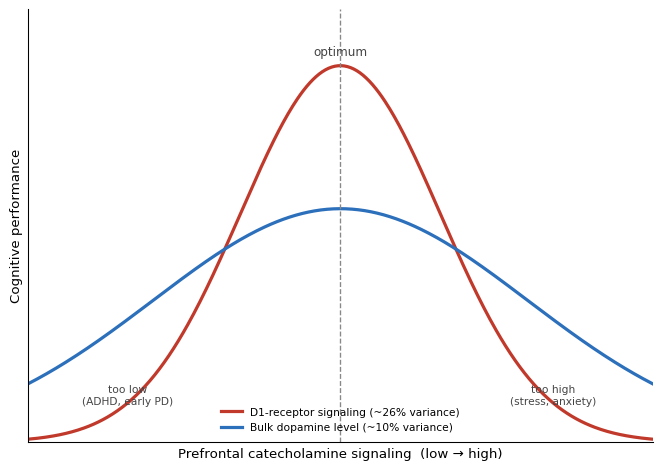

Figure 1: Schematic inverted-U relationship between prefrontal catecholamine signaling and cognitive performance, informed by the meta-analytic findings of Weber et al. (2022). Performance peaks at an intermediate level. The red curve (D1-receptor signaling) is steeper and accounts for more performance variance (~26%) than bulk dopamine level (blue, ~10%). Clinical states map onto positions along the axis: deficient tone (e.g., ADHD, early Parkinson’s disease) sits left of the optimum; excessive tone (e.g., acute stress, anxiety) sits right of it. The same drug moves a patient rightward, helping those who start low and harming those already near the peak.

# 3 Scope and evidence base

This is a narrative synthesis rather than a formal meta-analysis. We prioritized quantitative evidence: meta-analyses and systematic reviews where available, then controlled pharmacological and genetic-stratification trials in humans, human PET and fMRI studies, and mechanistic animal work (pharmacology, lesions, region-specific depletions). For each domain we report effect sizes (Cohen’s *d*, standardized mean differences, variance explained) when the primary literature provides them, note species and clinical population, and explicitly flag findings that resist the inverted-U account. Throughout, we compare clinical populations (ADHD, anxiety, autism spectrum, Parkinson’s disease, depression) against neurotypical baselines, because the framework’s central claim — that drug effects depend on baseline tone — can only be tested by such comparison.

# 4 Domain 1 — Attention and attentional control

Attention is the gating function the PFC and its noradrenergic input perform on incoming information. Phasic LC-NE bursts enhance the cortical encoding of salient, task-relevant signals while moderate tone keeps the fronto-parietal control network engaged; in large human samples, stronger intrinsic coupling between the LC and the salience network (anterior insula, anterior cingulate) is associated with better attentional ability, whereas weak LC–salience coupling tracks attentional deficits (Neal et al. 2023; Aston-Jones and Cohen 2005). Push tone too high, however — as in stress or anxiety — and elevated *tonic* NE produces over-arousal and hypervigilance, with attention captured by threat and novelty at the expense of goal-directed focus. Causal animal work confirms the direction: raising tonic LC firing while blunting phasic responsiveness induces exactly this over-alert, distractible state (Breton-Provencher and Sur 2019). This is the Yerkes–Dodson curve made neural: too little NE yields drowsy inattention, too much yields scattered hypervigilance, and the middle supports peak vigilance (Yerkes and Dodson 1908).

**ADHD — starting left of the optimum.** ADHD is, in this framework, a state of deficient PFC catecholamine tone — too far left on Figure 1 — and stimulants (methylphenidate, amphetamines) act by blocking DA/NE reuptake to move patients toward the optimum (Arnsten 2011). A meta-analysis of 36 pediatric trials found methylphenidate superior to placebo across attention-related measures, with effect sizes in the small-to-moderate range: reaction time SMD ≈ 0.29, reaction-time *variability* SMD ≈ 0.73, and response inhibition SMD ≈ 0.32 (Coghill et al. 2014). The variability effect is the largest, fitting the idea that stimulants reduce moment-to-moment neural noise rather than simply speeding processing. Critically, the benefit is not uniform: baseline performance moderates response, with the children who start with the poorest inhibitory control and attention gaining the most (Fosco et al. 2021). Stimulants “lift up” those furthest below the optimum more than those already near it — precisely the inverted-U prediction.

**Anxiety — starting right of the optimum.** In anxiety disorders the catecholamine problem is inverted: noradrenergic tone is too high. Stress peptides drive LC firing, NE floods amygdala and cortical targets, and attention is biased toward threat (Arnsten 2009). Here the therapeutic move is *down*-regulation — β-adrenergic blockade (propranolol) blunts hyperarousal and has shown efficacy against trauma-related hyper-reactivity — rebalancing the salience filter toward neutral, goal-relevant cues.

**Autism — a different correlational structure.** PET imaging found no gross group difference in striatal D1-receptor or thalamic NE-transporter binding between autistic adults and controls; what differed was the *correlational architecture*: within the autistic group, higher striatal D1 binding tracked *lower* “attention to detail” scores, and the NE-transporter–executive-function correlations seen in controls were absent (Kubota et al. 2020). The implication is subtle but important — atypical attention in autism may reflect altered *coupling* between catecholamine signaling and behavior rather than a simple surplus or deficit of the transmitter.

# 5 Domain 2 — Working memory and executive control

Working memory — holding and manipulating information over seconds — is the canonical inverted-U domain and the one with the hardest quantitative backbone. The 75-study meta-analysis establishes the negative quadratic relationship between prefrontal dopamine and WM accuracy, and shows that **D1-receptor signaling explains roughly 26% of WM variance versus ~10% for dopamine level** (Weber et al. 2022). Mechanistically, moderate D1 tone improves signal-to-noise by quieting background firing and sharpening tuned delay-period activity; too little leaves representations weak and distractible, too much suppresses firing across the board (Arnsten 2011; Cools and D’Esposito 2011).

**Baseline-dependent drug reversals.** The strongest evidence that the curve is real comes from manipulations that *flip sign* with baseline. In aged monkeys with low PFC dopamine, a D1 agonist improves WM (moving them up the left limb); in young monkeys with normal tone, the same dose is neutral or harmful (Arnsten 2011). In humans, COMT genotype — which sets prefrontal dopamine breakdown and hence baseline tone — predicts the direction of amphetamine’s effect on WM: enhancement in low-dopamine (Val/Val) individuals, impairment in high-dopamine (Met/Met) individuals (Cools and D’Esposito 2011). One drug, opposite effects, fully explained by starting position.

**The noradrenergic half.** NE tunes WM mainly through post-synaptic α2A-adrenoceptors: moderate NE strengthens the recurrent PFC connectivity that sustains a memory across a delay, which is why the α2A agonist guanfacine improves WM and attention (Arnsten 2011). Under acute stress, excess NE shifts to lower-affinity α1-receptors, triggering intracellular cascades (elevated cAMP, ion-channel modulation) that degrade the tuning and functionally take the PFC “offline,” handing control to subcortical structures (Arnsten 2009). The stability the system normally provides collapses — an arrangement that is maladaptive in an exam but adaptive when a genuine emergency demands fast, habit-driven action.

**Clinical anchors.** In ADHD, stimulants improve WM with modest effect sizes (executive-memory SMD ≈ 0.26 in meta-analysis), again largest in those with the poorest baseline (Coghill et al. 2014; Fosco et al. 2021). In Parkinson’s disease, dopamine replacement helps frontally dependent WM but illustrates the region-specificity caveat: L-DOPA raises dopamine globally and can overdose intact circuits even while treating depleted ones (Cools 2019).

**A contradiction worth keeping.** The framework is not unfalsifiable, and at least one result strains it. While the *meta-analytic* picture is a clean inverted-U, the modest variance explained — even D1 leaves ~74% unaccounted (Weber et al. 2022) — and reports of weak or absent correlations between individual dopamine-synthesis capacity and WM span suggest the relationship is non-linear, task-specific, and confounded by compensatory mechanisms (e.g., receptor up-regulation) rather than a tidy one-to-one mapping. The inverted-U is the central tendency, not the whole story.

# 6 Domain 3 — Cognitive flexibility and set-shifting

If working memory is the stability domain, cognitive flexibility is the flexibility domain — and here **D2 receptors take the lead** (Holstein et al. 2011; Cools 2019). The decisive human evidence is a placebo-controlled, genotype-stratified, antagonist-controlled design: the D2 agonist bromocriptine improved task-switching, but *only* in subjects with genetically low dopamine; the benefit vanished in higher-dopamine subjects and was abolished by pre-treatment with the D2 antagonist sulpiride — pinning the effect to D2 signaling and to baseline state simultaneously (Holstein et al. 2011). This is the inverted-U and the receptor mechanism demonstrated in one experiment.

Mechanistically, D2 activation *weakens* the current attractor state, allowing new information to reshape the network — exactly what switching requires — whereas D1-dominated stability promotes perseveration when it dominates (Cools 2019; Floresco 2013). The trade-off has a sweet spot: too little D2 drive leaves thinking inert and perseverative; too much produces chaotic, undirected switching and impaired learning from feedback. In high-dopamine individuals a low dose of a D2 *blocker* can paradoxically improve performance by quieting an over-destabilized baseline (Cools 2019).

Animal work adds anatomy: striatal dopamine is needed to *implement* an intentional switch (depletions in dorsomedial striatum or caudate impair reversal and shifting), while wholesale removal of PFC catecholamines can superficially *ease* an extradimensional shift — but only because the animal can no longer maintain the original set. That is faux-flexibility from a loss of stability, not improved control (Robbins and Arnsten 2009; Cools 2019) — a clean illustration of why “more switching” is not the same as “better flexibility,” and of the stability–flexibility trade-off at the core of the framework. Parkinson’s disease again shows both sides: dopaminergic medication can restore shifting on dorsally dependent tasks while degrading reversal learning on ventrally dependent ones in the same patient, depending on dose and circuit (Cools 2019).

# 7 Domain 4 — Salience detection and processing

Salience is the brain’s triage system — what gets flagged as worth processing — and it is a joint DA/NE venture. NE provides general, fast importance-tagging: phasic LC bursts coincide with the detection of task-relevant cues and reconfigure large-scale networks, increasing connectivity within the salience network and switching the brain from internally focused (default-mode) to externally engaged (task-positive) states (Aston-Jones and Cohen 2005; Neal et al. 2023). Dopamine provides the *valuation* component: midbrain DA neurons fire to unexpected, motivationally significant events, tagging cues as worth approaching and learning about — the “incentive salience” or “wanting” signal that is dissociable from hedonic pleasure itself (Berridge and Robinson 1998).

When the salience system mis-calibrates, the consequences are clinically legible. **Schizophrenia** offers the sharpest illustration of dopamine’s salience role: the aberrant-salience hypothesis holds that excessive striatal dopamine attaches significance to trivial stimuli, and that delusions are the patient’s effort to explain this misplaced importance — which is why D2-blocking antipsychotics dampen salience and extinguish the false associations (Kapur 2003). **ADHD** sits at the opposite extreme: blunted phasic dopamine means genuine rewards fail to capture sustained attention, so patients need larger or more immediate incentives, while weak PFC regulation lets trivial distractors through — distractibility and reward-insensitivity as two faces of under-tagged salience, both improved by stimulants that raise the striatal dopamine response to meaningful cues (Arnsten 2011). **Anxiety/PTSD** is over-tagging driven by high tonic NE — a world in which every shadow is flagged as threat, normalized by lowering noradrenergic tone (Arnsten 2009; Breton-Provencher and Sur 2019). **Autism** shows a re-ordered salience hierarchy rather than uniformly high or low salience: reduced orienting to social cues alongside intense focus on specific non-social interests, a pattern plausibly rooted in atypical DA/NE coupling — consistent with the altered correlational structure between catecholamine binding and behavior reported in Kubota et al. (2020).

The throughline: dopamine biases the organism toward what is *worth pursuing* while norepinephrine signals *pay attention now*. Balanced, they yield appropriate focus — turning to a speaker who says your name, stopping at a red light. Imbalanced, they produce the characteristic salience pathologies of each disorder.

# 8 Domain 5 — Mood, motivation, and emotion regulation

Catecholamines do not stop at cognition; the same chemicals and largely the same circuits set motivation and affect. Dopamine, especially along the mesolimbic pathway (ventral tegmental area → nucleus accumbens and frontal cortex), underwrites reward, drive, and the *anticipation* of pleasure. Anhedonia — the loss of interest and motivation that is a core symptom of major depression — has long been modeled as blunted dopaminergic function, and the modern account sharpens this: the deficit is less in “liking” (consummatory pleasure) than in “wanting” and in the willingness to *work* for reward, an effort–value computation that dopamine directly supports (Treadway and Zald 2011; Cooper, Arulpragasam, and Treadway 2018). Imaging is broadly consistent — reduced striatal dopamine release to reward and altered D2/D3 availability in depression — though findings are mixed enough to suggest pathophysiological subtypes (e.g., an inflammation-linked subtype) rather than one uniform dopamine lesion (Cooper, Arulpragasam, and Treadway 2018).

Therapeutically, the prediction holds: pro-dopaminergic interventions preferentially relieve anhedonia and low motivation. Bupropion (a DA/NE reuptake inhibitor) targets exactly these symptoms, stimulants are used off-label for refractory amotivation, and the effort-based-decision-making framework explains *why* these agents act on drive specifically rather than mood globally (Treadway and Zald 2011; Cooper, Arulpragasam, and Treadway 2018). Norepinephrine contributes the energy-and-arousal axis of mood: too little tracks the fatigue and psychomotor retardation of depression (SNRIs such as venlafaxine and duloxetine help partly by raising it), too much tracks the hyperarousal of anxiety — its own inverted-U, mirroring the attentional one (Arnsten 2009). The two systems also interact: LC projections modulate midbrain dopamine firing, so a low-NE state can indirectly blunt phasic dopamine and compound anhedonia.

The same disorders recur, now from the affective angle. Parkinson’s disease carries high rates of depression tied to mesolimbic dopamine loss, partly responsive to dopaminergic therapy; antipsychotic D2 blockade can induce affective blunting as an iatrogenic anhedonia — the mirror image, confirming the link (Kapur 2003). The unifying statement is the same as for cognition: balanced catecholamine tone permits adaptive movement between affective states, while the extremes — apathetic depression at one pole, anxious hyperarousal at the other — are the mood-domain expression of too little versus too much.

# 9 Discussion

## 9.1 What the framework buys us

Across five domains the same small toolkit recurs. The **inverted-U** explains why catecholaminergic drugs are not uniformly pro-cognitive: they shift a patient rightward, which helps those starting low and harms those starting high — demonstrated most cleanly by the baseline-dependent sign reversals in monkeys (aged vs. young), in humans by COMT genotype, and by genotype-stratified bromocriptine (Arnsten 2011; Cools and D’Esposito 2011; Holstein et al. 2011). The **D1/D2 stability–flexibility** division explains why the optimum is task-dependent: working memory wants D1-mediated stability, set-shifting wants D2-mediated flexibility, and no single dopamine level is best for both (Cools 2019; Floresco 2013). The **LC adaptive-gain** account ports the same logic to arousal and attention (Aston-Jones and Cohen 2005), and the **region/receptor-specificity** caveat explains the Parkinson’s “overdose” dissociations that a one-number model cannot (Cools 2019).

## 9.2 Clinical implications: one curve, many disorders

The disorders surveyed here line up along Figure 1 rather than into separate silos. **ADHD** and **early Parkinson’s disease** sit left of the optimum (deficient tone, helped by raising it); **acute stress** and **anxiety/PTSD** sit right (excess tone, helped by lowering it); **depression** is a deficit on the motivational/dopamine axis; **autism** is better described as altered coupling and a re-ordered salience hierarchy than as a simple shift along one axis. The actionable consequence is that the *direction* of treatment is set by baseline tone, and effect sizes are modest precisely because cohorts mix patients at different positions on the curve — averaging left-limb responders with near-peak non-responders dilutes the mean (Coghill et al. 2014; Fosco et al. 2021).

## 9.3 Limitations and contradictions

Honesty requires naming what the framework does not yet absorb. (i) Even the best single predictor — D1 signaling — leaves the large majority of working-memory variance unexplained, and some large-sample studies find weak links between individual dopamine metrics and cognition, implying strong moderation and compensation rather than a tidy function (Weber et al. 2022). (ii) Much of the mechanistic precision (region-specific depletions, receptor-level dissociations) comes from rodents and non-human primates; human evidence is largely correlational or relies on coarse pharmacological and genetic proxies for “tone.” (iii) “Catecholamine tone” is itself a simplification — phasic vs. tonic firing, receptor subtype, regional concentration, and serotonergic/cholinergic interactions all matter, and collapsing them onto one x-axis is a useful cartoon, not a measurement. (iv) The neurochemistry of autism in particular is heterogeneous enough that group means hide opposing subtypes (Kubota et al. 2020).

## 9.4 Future directions

The framework points to a concrete program. **Individual-level prediction**: combine genotype (e.g., COMT), PET/neuromelanin estimates of dopaminergic and LC integrity, and baseline cognitive performance to estimate where a patient sits on the curve *before* prescribing (Fosco et al. 2021). **Dynamic measurement**: pupillometry and fast imaging to track phasic vs. tonic catecholamine states during tasks rather than inferring tone from a single scan (Aston-Jones and Cohen 2005). **Circuit-specific intervention**: receptor- and region-selective agents (e.g., α2A or D1-selective compounds) that move one circuit without overdosing another (Cools 2019). The destination is precision psychiatry: matching catecholaminergic treatment to a measured neurochemical position rather than to a symptom label.

# 10 Conclusions

Dopamine and norepinephrine tune prefrontal cognition along an inverted-U: optimal mid-range signaling supports attention, working-memory stability, cognitive flexibility, calibrated salience, and positive mood, while deficits and excesses both impair — in opposite ways and through different receptors. The framework’s power is that it turns a contradictory drug literature into a single prediction (the effect depends on baseline position), is quantitatively anchored (a 75-study meta-analysis; D1 signaling explaining ~26% of working-memory variance), and is mechanistically specified (D1 stability vs. D2 flexibility, LC adaptive gain, region/receptor specificity). It also names its own limits: most variance remains unexplained, the strongest mechanistic evidence is from animals, and “tone” is a simplification. The practical horizon is clear — measure where a person sits on the curve, then move them toward the optimum rather than simply adding or subtracting catecholamines.

# References

Arnsten, Amy F. T. 2009. “Stress Signalling Pathways That Impair Prefrontal Cortex Structure and Function.” *Nature Reviews Neuroscience* 10 (6): 410–22. https://doi.org/10.1038/nrn2648.

———. 2011. “Catecholamine Influences on Dorsolateral Prefrontal Cortical Networks.” *Biological Psychiatry* 69 (12): e89–99. https://doi.org/10.1016/j.biopsych.2011.01.027.

Aston-Jones, Gary, and Jonathan D. Cohen. 2005. “An Integrative Theory of Locus Coeruleus-Norepinephrine Function: Adaptive Gain and Optimal Performance.” *Annual Review of Neuroscience* 28: 403–50. https://doi.org/10.1146/annurev.neuro.28.061604.135709.

Berridge, Kent C., and Terry E. Robinson. 1998. “What Is the Role of Dopamine in Reward: Hedonic Impact, Reward Learning, or Incentive Salience?” *Brain Research Reviews* 28 (3): 309–69. https://doi.org/10.1016/S0165-0173(98)00019-8.

Breton-Provencher, Vincent, and Mriganka Sur. 2019. “Active Control of Arousal by a Locus Coeruleus GABAergic Circuit.” *Nature Neuroscience* 22 (2): 218–28. https://doi.org/10.1038/s41593-018-0305-z.

Coghill, David R., Sagar Seth, Stephanie Pedroso, Tobias Usala, Jurate Currie, and Antonella Gagliano. 2014. “Effects of Methylphenidate on Cognitive Functions in Children and Adolescents with Attention-Deficit/Hyperactivity Disorder: Evidence from a Systematic Review and a Meta-Analysis.” *Biological Psychiatry* 76 (8): 603–15. https://doi.org/10.1016/j.biopsych.2013.10.005.

Cools, Roshan. 2019. “Chemistry of the Adaptive Mind: Lessons from Dopamine.” *Neuron* 104 (1): 113–31. https://doi.org/10.1016/j.neuron.2019.09.035.

Cools, Roshan, and Mark D’Esposito. 2011. “Inverted-U-Shaped Dopamine Actions on Human Working Memory and Cognitive Control.” *Biological Psychiatry* 69 (12): e113–25. https://doi.org/10.1016/j.biopsych.2011.03.028.

Cooper, Jessica A., Amanda R. Arulpragasam, and Michael T. Treadway. 2018. “Anhedonia in Depression: Biological Mechanisms and Computational Models.” *Current Opinion in Behavioral Sciences* 22: 128–35. https://doi.org/10.1016/j.cobeha.2018.01.024.

Floresco, Stan B. 2013. “Prefrontal Dopamine and Behavioral Flexibility: Shifting from an "Inverted-U" Toward a Family of Functions.” *Frontiers in Neuroscience* 7: 62. https://doi.org/10.3389/fnins.2013.00062.

Fosco, Whitney D., Keri S. Rosch, James G. Waxmonsky, William E. Pelham, and Larry W. Hawk. 2021. “Baseline Performance Moderates Stimulant Effects on Cognition in Youth with ADHD.” *Experimental and Clinical Psychopharmacology* 29 (4): 302–7. https://doi.org/10.1037/pha0000366.

Holstein, Mieke van, Esther Aarts, Marieke E. van der Schaaf, Dirk E. M. Geurts, Robbert J. Verkes, Barbara Franke, Martine R. van Schouwenburg, and Roshan Cools. 2011. “Human Cognitive Flexibility Depends on Dopamine D2 Receptor Signaling.” *Psychopharmacology* 218 (3): 567–78. https://doi.org/10.1007/s00213-011-2340-2.

Kapur, Shitij. 2003. “Psychosis as a State of Aberrant Salience: A Framework Linking Biology, Phenomenology, and Pharmacology in Schizophrenia.” *American Journal of Psychiatry* 160 (1): 13–23. https://doi.org/10.1176/appi.ajp.160.1.13.

Kubota, Manabu, Junya Fujino, Shisei Tei, Keisuke Takahata, Kiwamu Matsuoka, Kenji Tagai, Yasunori Sano, Yasuharu Yamamoto, Tetsuya Suhara, and Hidehiko Takahashi. 2020. “Binding of Dopamine D1 Receptor and Noradrenaline Transporter in Individuals with Autism Spectrum Disorder: A PET Study.” *Cerebral Cortex* 30 (12): 6458–68. https://doi.org/10.1093/cercor/bhaa211.

Neal, Joshua, Inuk Song, Benjamin Katz, and Tae-Ho Lee. 2023. “Association of Intrinsic Functional Connectivity Between the Locus Coeruleus and Salience Network with Attentional Ability.” *Journal of Cognitive Neuroscience* 35 (10): 1557–69. https://doi.org/10.1162/jocn_a_02036.

Robbins, Trevor W., and Amy F. T. Arnsten. 2009. “The Neuropsychopharmacology of Fronto-Executive Function: Monoaminergic Modulation.” *Annual Review of Neuroscience* 32: 267–87. https://doi.org/10.1146/annurev.neuro.051508.135535.

Treadway, Michael T., and David H. Zald. 2011. “Reconsidering Anhedonia in Depression: Lessons from Translational Neuroscience.” *Neuroscience and Biobehavioral Reviews* 35 (3): 537–55. https://doi.org/10.1016/j.neubiorev.2010.06.006.

Weber, Matthew A., Mackenzie M. Conlon, Hannah R. Stutt, Linder Wendt, Patrick Ten Eyck, and Nandakumar S. Narayanan. 2022. “Quantifying the Inverted U: A Meta-Analysis of Prefrontal Dopamine, D1-Receptors, and Working Memory.” *Behavioral Neuroscience* 136 (3): 207–18. https://doi.org/10.1037/bne0000512.

Yerkes, Robert M., and John D. Dodson. 1908. “The Relation of Strength of Stimulus to Rapidity of Habit-Formation.” *Journal of Comparative Neurology and Psychology* 18 (5): 459–82. https://doi.org/10.1002/cne.920180503.